# WET Data Exploration: Surface Water & Hydroperiod

Maddee Wiggins

2026-08-07

```r
library(tidyverse)
library(terra)
library(ggplot2)
library(scales)
library(patchwork)
library(knitr)
```

# Overview

This document explores the Intermountain West WET (Wetland Extent Tool) raster dataset stored in `data-raw/intermountain-west-data/`. The dataset contains two product types:

- **SurfaceWater**: monthly estimates of open water extent (probability/presence)
- **Hydroperiod**: monthly estimates of how long water persists (hydroperiod duration)

Both products are available at decadal time steps and, for SurfaceWater, as individual monthly images from 2022 onward.

# 1. Inventory & File Parsing

```r
data_dir <- here::here("data-raw", "intermountain-west-data")

tif_files <- list.files(data_dir, pattern = "\\.tif$", full.names = TRUE)

# Parse filename metadata
month_lookup <- c(
  JAN = 1, FEB = 2, MAR = 3, APR = 4, MAY = 5, JUN = 6,
  JUL = 7, AUG = 8, SEP = 9, OCT = 10, NOV = 11, DEC = 12
)

file_meta <- tibble(path = tif_files) |>
  mutate(
    filename  = basename(path) |> str_remove("\\.tif$"),
    type      = case_when(
      str_starts(filename, "SurfaceWater")  ~ "SurfaceWater",
      str_starts(filename, "Hydroperiod")   ~ "Hydroperiod"
    ),
    rest      = str_remove(filename, type),
    month_chr = str_extract(rest, "[A-Z]{3}$"),
    era_str   = str_remove(rest, "[A-Z]{3}$"),
    month_num = month_lookup[month_chr],
    is_decadal = str_detect(era_str, "-"),
    # For decadal: start year of the era; for annual: the single year
    era_start = as.integer(str_extract(era_str, "^[0-9]{4}"))
  )

kable(
  file_meta |>
    count(type, is_decadal, era_str) |>
    arrange(type, era_str),
  caption = "File counts by product type and era"
)
```

File counts by product type and era

| type | is_decadal | era_str | n |
| --- | --- | --- | --- |
| Hydroperiod | TRUE | 1984-1994 | 12 |
| Hydroperiod | TRUE | 1995-2004 | 12 |
| Hydroperiod | TRUE | 2005-2014 | 12 |
| Hydroperiod | TRUE | 2015-2022 | 12 |
| SurfaceWater | TRUE | 2005-2014 | 12 |
| SurfaceWater | TRUE | 2015-2022 | 12 |
| SurfaceWater | FALSE | 2022 | 12 |
| SurfaceWater | FALSE | 2023 | 12 |
| SurfaceWater | FALSE | 2024 | 12 |
| SurfaceWater | FALSE | 2025 | 12 |
| SurfaceWater | FALSE | 2026 | 4 |

```r
cat("Total files:", nrow(file_meta), "\n")
```

```
## Total files: 124
```

```r
cat("SurfaceWater files:", sum(file_meta$type == "SurfaceWater"), "\n")
```

```
## SurfaceWater files: 76
```

```r
cat("Hydroperiod files: ", sum(file_meta$type == "Hydroperiod"), "\n\n")
```

```
## Hydroperiod files:  48
```

```r
cat("SurfaceWater eras:\n")
```

```
## SurfaceWater eras:
```

```r
file_meta |> filter(type == "SurfaceWater") |> pull(era_str) |> unique() |> sort() |> paste(collapse = ", ") |> cat("\n\n")
```

```
## 2005-2014, 2015-2022, 2022, 2023, 2024, 2025, 2026
```

```r
cat("Hydroperiod eras:\n")
```

```
## Hydroperiod eras:
```

```r
file_meta |> filter(type == "Hydroperiod") |> pull(era_str) |> unique() |> sort() |> paste(collapse = ", ") |> cat("\n")
```

```
## 1984-1994, 1995-2004, 2005-2014, 2015-2022
```

# 2. Raster Properties

Check CRS, resolution, and extent from representative files.

```r
check_raster_props <- function(path) {
  r <- rast(path)
  tibble(
    file     = basename(path),
    crs      = crs(r, describe = TRUE)$name,
    nrow     = nrow(r),
    ncol     = ncol(r),
    res_x    = res(r)[1],
    res_y    = res(r)[2],
    xmin     = ext(r)$xmin,
    xmax     = ext(r)$xmax,
    ymin     = ext(r)$ymin,
    ymax     = ext(r)$ymax,
    val_min  = as.numeric(global(r, "min", na.rm = TRUE)),
    val_max  = as.numeric(global(r, "max", na.rm = TRUE))
  )
}

# Sample one SurfaceWater and one Hydroperiod file
sw_sample  <- file_meta |> filter(type == "SurfaceWater") |> slice(1) |> pull(path)
hp_sample  <- file_meta |> filter(type == "Hydroperiod")  |> slice(1) |> pull(path)

props <- bind_rows(
  check_raster_props(sw_sample),
  check_raster_props(hp_sample)
)

kable(t(props), caption = "Raster properties for representative files")
```

Raster properties for representative files

| file | SurfaceWater2005-2014APR.tif | Hydroperiod1984-1994APR.tif |
| --- | --- | --- |
| crs | WGS 84 | WGS 84 |
| nrow | 7662 | 7662 |
| ncol | 7339 | 7339 |
| res_x | 0.0002694946 | 0.0002694946 |
| res_y | 0.0002694946 | 0.0002694946 |
| xmin | -122.5058 | -122.5058 |
| xmax | -120.5279 | -120.5279 |
| ymin | 41.3658 | 41.3658 |
| ymax | 43.43067 | 43.43067 |
| val_min | 0.1614438 | 1.0000000 |
| val_max | 0.1667646 | 12.0000000 |

# 3. Load & Aggregate All Rasters

Read each file, extract the mean pixel value across the scene, and build tidy summary data frames for both products.

```r
extract_scene_summary <- function(path) {
  r   <- rast(path)
  vals <- values(r, na.rm = TRUE)
  tibble(
    mean_val   = mean(vals),
    median_val = median(vals),
    sd_val     = sd(vals),
    pct_wet    = mean(vals > 0),    # fraction of pixels with any water
    n_pixels   = length(vals)
  )
}

message("Loading ", nrow(file_meta), " rasters — this may take a moment...")

scene_stats <- file_meta |>
  mutate(stats = map(path, extract_scene_summary)) |>
  unnest(stats)

sw_data <- scene_stats |> filter(type == "SurfaceWater")
hp_data <- scene_stats |> filter(type == "Hydroperiod")

cat("SurfaceWater dataset:", nrow(sw_data), "rows\n")
```

```
## SurfaceWater dataset: 76 rows
```

```r
cat("Hydroperiod dataset: ", nrow(hp_data), "rows\n")
```

```
## Hydroperiod dataset:  48 rows
```

# 4. Surface Water Exploration

## 4.1 Dataset summary

```r
summary(sw_data |> select(era_str, month_num, mean_val, median_val, sd_val, pct_wet))
```

```
##    era_str            month_num         mean_val         median_val
##  Length:76          Min.   : 1.000   Min.   :0.08808   Min.   :0.0000
##  Class :character   1st Qu.: 3.000   1st Qu.:0.16424   1st Qu.:0.1640
##  Mode  :character   Median : 6.000   Median :0.24077   Median :0.1642
##                     Mean   : 6.289   Mean   :0.41820   Mean   :0.4037
##                     3rd Qu.: 9.000   3rd Qu.:0.72406   3rd Qu.:0.7738
##                     Max.   :12.000   Max.   :0.80819   Max.   :0.9088
##      sd_val             pct_wet
##  Min.   :0.0009914   Min.   :0.1630
##  1st Qu.:0.0010800   1st Qu.:1.0000
##  Median :0.2200645   Median :1.0000
##  Mean   :0.1894715   Mean   :0.8269
##  3rd Qu.:0.3061843   3rd Qu.:1.0000
##  Max.   :0.3939732   Max.   :1.0000
```

## 4.2 Mean surface water extent by month (decadal eras)

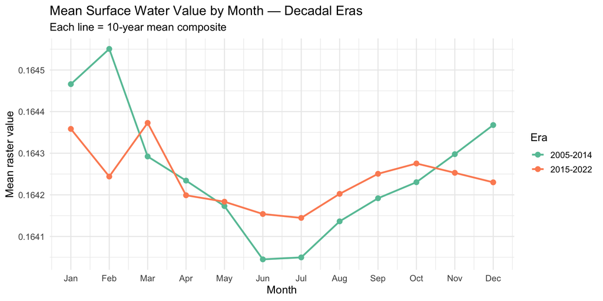

```r
sw_decadal <- sw_data |> filter(is_decadal)

ggplot(sw_decadal, aes(x = month_num, y = mean_val, color = era_str, group = era_str)) +
  geom_line(linewidth = 1) +
  geom_point(size = 2.5) +
  scale_x_continuous(breaks = 1:12, labels = month.abb) +
  scale_color_brewer(palette = "Set2", name = "Era") +
  labs(
    title    = "Mean Surface Water Value by Month — Decadal Eras",
    x        = "Month",
    y        = "Mean raster value",
    subtitle = "Each line = 10-year mean composite"
  ) +
  theme_minimal(base_size = 13)
```

## 4.3 Fraction of wet pixels by month (decadal eras)

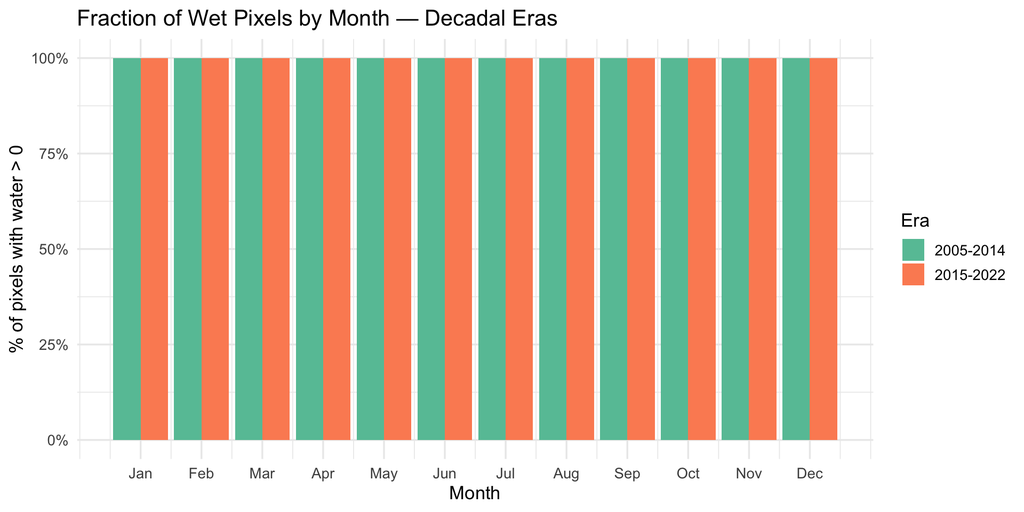

```r
ggplot(sw_decadal, aes(x = month_num, y = pct_wet, fill = era_str)) +
  geom_col(position = "dodge") +
  scale_x_continuous(breaks = 1:12, labels = month.abb) +
  scale_y_continuous(labels = percent_format()) +
  scale_fill_brewer(palette = "Set2", name = "Era") +
  labs(
    title = "Fraction of Wet Pixels by Month — Decadal Eras",
    x     = "Month",
    y     = "% of pixels with water > 0"
  ) +
  theme_minimal(base_size = 13)
```

## 4.4 Annual time series (individual years 2022–2026)

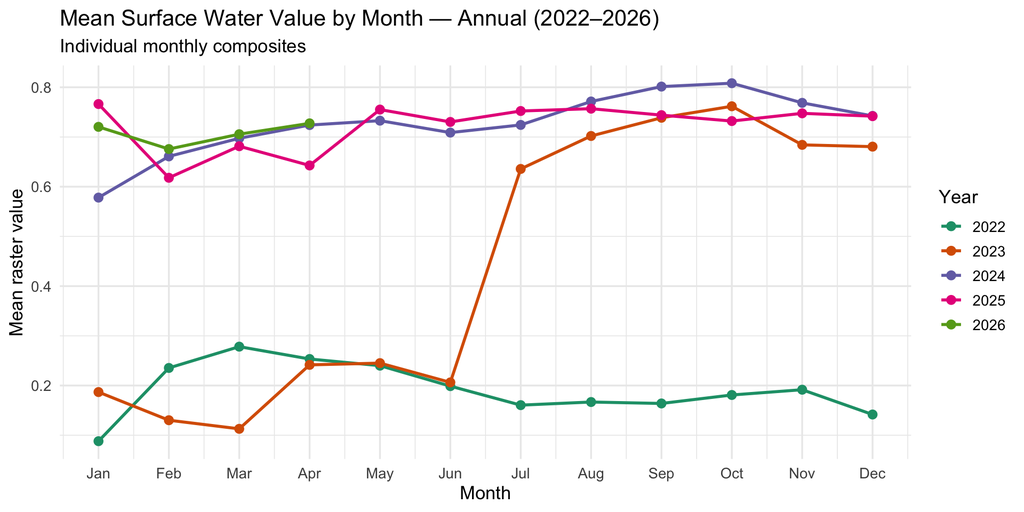

```r
sw_annual <- sw_data |> filter(!is_decadal)

ggplot(sw_annual, aes(x = month_num, y = mean_val, color = factor(era_start), group = era_start)) +
  geom_line(linewidth = 1) +
  geom_point(size = 2.5) +
  scale_x_continuous(breaks = 1:12, labels = month.abb) +
  scale_color_brewer(palette = "Dark2", name = "Year") +
  labs(
    title    = "Mean Surface Water Value by Month — Annual (2022–2026)",
    x        = "Month",
    y        = "Mean raster value",
    subtitle = "Individual monthly composites"
  ) +
  theme_minimal(base_size = 13)
```

## 4.5 Wet fraction heatmap — annual years

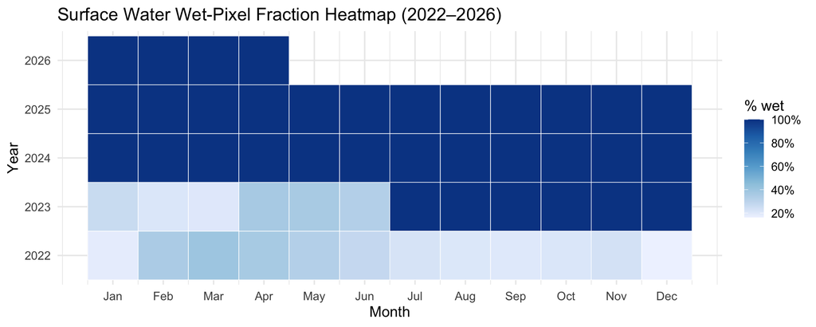

```r
sw_annual |>
  mutate(year = factor(era_start)) |>
  ggplot(aes(x = month_num, y = year, fill = pct_wet)) +
  geom_tile(color = "white") +
  scale_x_continuous(breaks = 1:12, labels = month.abb) +
  scale_fill_distiller(palette = "Blues", direction = 1,
                       labels = percent_format(), name = "% wet") +
  labs(
    title = "Surface Water Wet-Pixel Fraction Heatmap (2022–2026)",
    x     = "Month",
    y     = "Year"
  ) +
  theme_minimal(base_size = 13)
```

## 4.6 Value distribution — annual months

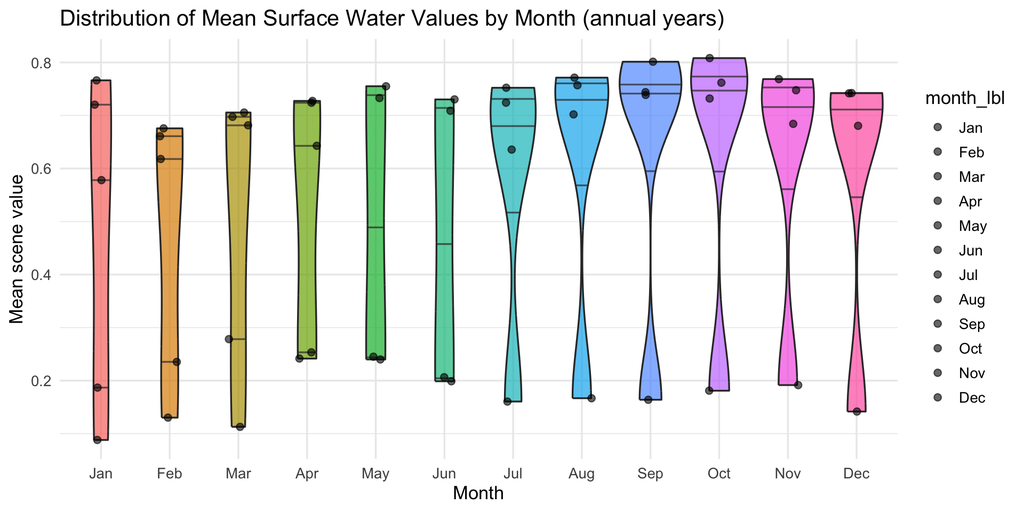

```r
sw_annual |>
  mutate(month_lbl = factor(month.abb[month_num], levels = month.abb)) |>
  ggplot(aes(x = month_lbl, y = mean_val, fill = month_lbl)) +
  geom_violin(draw_quantiles = c(0.25, 0.5, 0.75), alpha = 0.7, show.legend = FALSE) +
  geom_jitter(width = 0.15, size = 2, alpha = 0.6) +
  labs(
    title = "Distribution of Mean Surface Water Values by Month (annual years)",
    x     = "Month",
    y     = "Mean scene value"
  ) +
  theme_minimal(base_size = 13)
```

# 5. Hydroperiod Exploration

## 5.1 Dataset summary

```r
summary(hp_data |> select(era_str, month_num, mean_val, median_val, sd_val, pct_wet))
```

```
##    era_str            month_num        mean_val        median_val
##  Length:48          Min.   : 1.00   Min.   : 7.708   Min.   : 8.00
##  Class :character   1st Qu.: 3.75   1st Qu.: 8.599   1st Qu.:10.00
##  Mode  :character   Median : 6.50   Median : 9.650   Median :11.00
##                     Mean   : 6.50   Mean   : 9.672   Mean   :10.94
##                     3rd Qu.: 9.25   3rd Qu.:10.800   3rd Qu.:12.00
##                     Max.   :12.00   Max.   :11.642   Max.   :12.00
##      sd_val         pct_wet
##  Min.   :1.112   Min.   :1
##  1st Qu.:2.359   1st Qu.:1
##  Median :3.176   Median :1
##  Mean   :2.881   Mean   :1
##  3rd Qu.:3.560   3rd Qu.:1
##  Max.   :4.105   Max.   :1
```

## 5.2 Mean hydroperiod value by month across eras

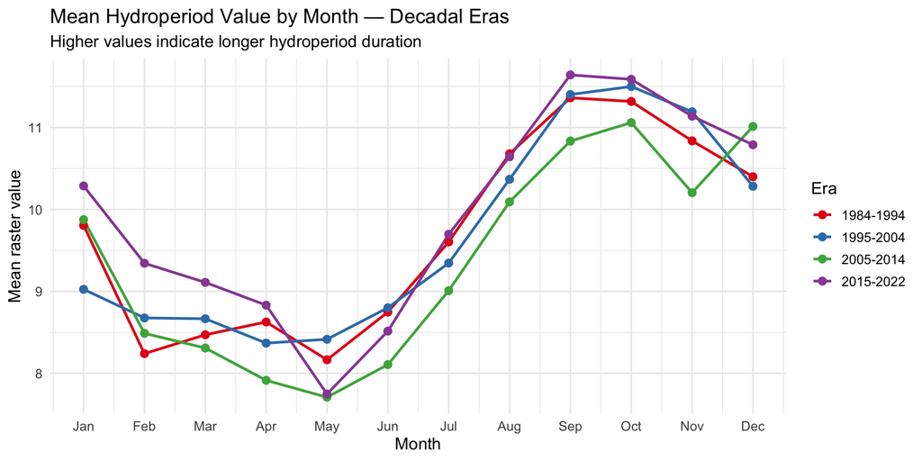

```r
ggplot(hp_data, aes(x = month_num, y = mean_val, color = era_str, group = era_str)) +
  geom_line(linewidth = 1) +
  geom_point(size = 2.5) +
  scale_x_continuous(breaks = 1:12, labels = month.abb) +
  scale_color_brewer(palette = "Set1", name = "Era") +
  labs(
    title    = "Mean Hydroperiod Value by Month — Decadal Eras",
    x        = "Month",
    y        = "Mean raster value",
    subtitle = "Higher values indicate longer hydroperiod duration"
  ) +
  theme_minimal(base_size = 13)
```

## 5.3 Fraction of persistently wet pixels by month

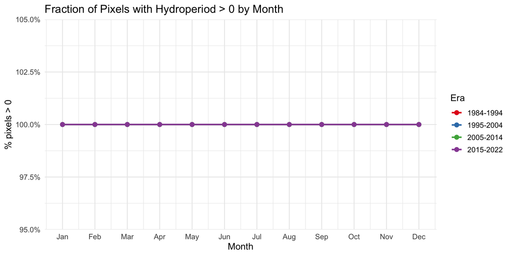

```r
ggplot(hp_data, aes(x = month_num, y = pct_wet, color = era_str, group = era_str)) +
  geom_line(linewidth = 1) +
  geom_point(size = 2.5) +
  scale_x_continuous(breaks = 1:12, labels = month.abb) +
  scale_y_continuous(labels = percent_format()) +
  scale_color_brewer(palette = "Set1", name = "Era") +
  labs(
    title = "Fraction of Pixels with Hydroperiod > 0 by Month",
    x     = "Month",
    y     = "% pixels > 0"
  ) +
  theme_minimal(base_size = 13)
```

## 5.4 Heatmap: mean hydroperiod by era × month

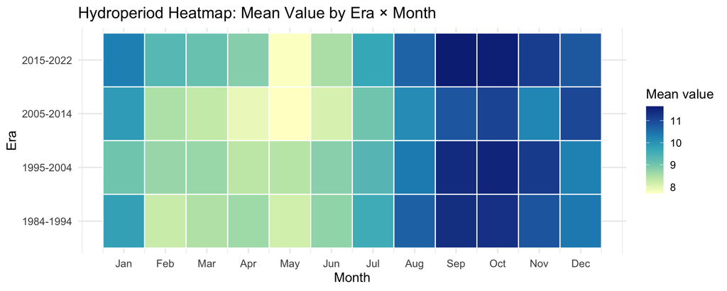

```r
hp_data |>
  ggplot(aes(x = month_num, y = era_str, fill = mean_val)) +
  geom_tile(color = "white", linewidth = 0.5) +
  scale_x_continuous(breaks = 1:12, labels = month.abb) +
  scale_fill_distiller(palette = "YlGnBu", direction = 1, name = "Mean value") +
  labs(
    title = "Hydroperiod Heatmap: Mean Value by Era × Month",
    x     = "Month",
    y     = "Era"
  ) +
  theme_minimal(base_size = 13)
```

## 5.5 Era-to-era change in annual mean hydroperiod

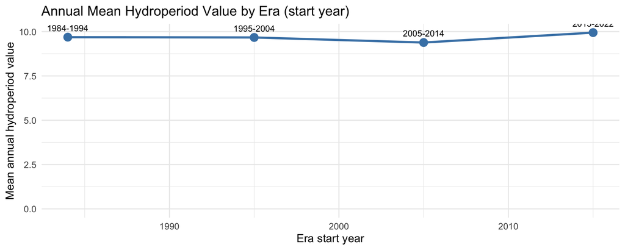

```r
hp_annual_mean <- hp_data |>
  group_by(era_str, era_start) |>
  summarise(annual_mean = mean(mean_val), .groups = "drop")

ggplot(hp_annual_mean, aes(x = era_start, y = annual_mean)) +
  geom_line(color = "steelblue", linewidth = 1.2) +
  geom_point(color = "steelblue", size = 4) +
  geom_text(aes(label = era_str), vjust = -1, size = 3.5) +
  expand_limits(y = 0) +
  labs(
    title = "Annual Mean Hydroperiod Value by Era (start year)",
    x     = "Era start year",
    y     = "Mean annual hydroperiod value"
  ) +
  theme_minimal(base_size = 13)
```

# 6. Surface Water vs. Hydroperiod Comparison

Compare the decadal eras common to both products (2005–2014 and 2015–2022).

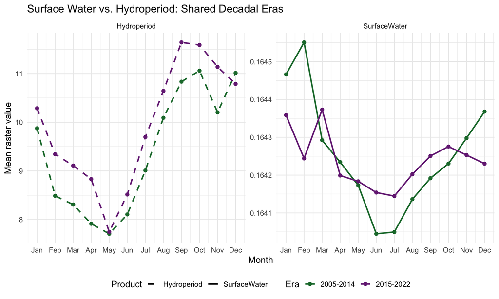

```r
shared_eras <- c("2005-2014", "2015-2022")

compare <- bind_rows(
  sw_data  |> filter(era_str %in% shared_eras) |> mutate(product = "SurfaceWater"),
  hp_data  |> filter(era_str %in% shared_eras) |> mutate(product = "Hydroperiod")
)

ggplot(compare, aes(x = month_num, y = mean_val, color = era_str, linetype = product)) +
  geom_line(linewidth = 1) +
  geom_point(size = 2) +
  scale_x_continuous(breaks = 1:12, labels = month.abb) +
  scale_color_manual(values = c("2005-2014" = "#1b7837", "2015-2022" = "#762a83"),
                     name = "Era") +
  scale_linetype_manual(values = c("SurfaceWater" = "solid", "Hydroperiod" = "dashed"),
                        name = "Product") +
  facet_wrap(~product, scales = "free_y") +
  labs(
    title = "Surface Water vs. Hydroperiod: Shared Decadal Eras",
    x     = "Month",
    y     = "Mean raster value"
  ) +
  theme_minimal(base_size = 13) +
  theme(legend.position = "bottom")
```

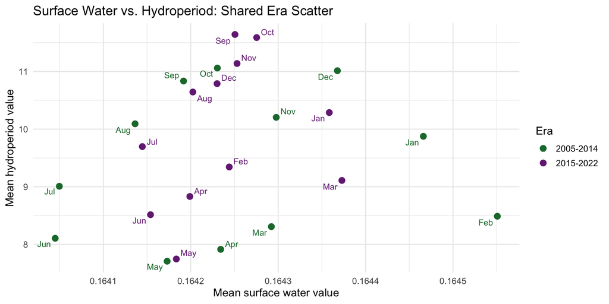

```r
sw_shared <- sw_data  |> filter(era_str %in% shared_eras) |>
  select(era_str, month_num, sw_mean = mean_val)
hp_shared <- hp_data  |> filter(era_str %in% shared_eras) |>
  select(era_str, month_num, hp_mean = mean_val)

joined <- inner_join(sw_shared, hp_shared, by = c("era_str", "month_num"))

ggplot(joined, aes(x = sw_mean, y = hp_mean, color = era_str, label = month.abb[month_num])) +
  geom_point(size = 3) +
  ggrepel::geom_text_repel(size = 3.5, max.overlaps = 20) +
  scale_color_manual(values = c("2005-2014" = "#1b7837", "2015-2022" = "#762a83"),
                     name = "Era") +
  labs(
    title = "Surface Water vs. Hydroperiod: Shared Era Scatter",
    x     = "Mean surface water value",
    y     = "Mean hydroperiod value"
  ) +
  theme_minimal(base_size = 13)
```

# 7. Representative Raster Maps

Plot one layer from each product to visually inspect the spatial data.

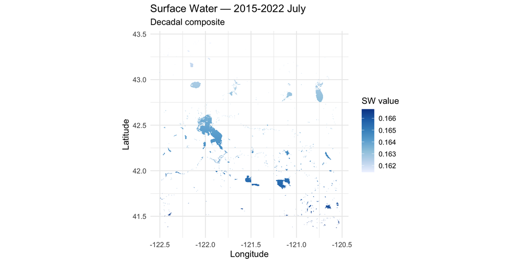

```r
sw_map_file <- file_meta |>
  filter(type == "SurfaceWater", era_str == "2015-2022", month_chr == "JUL") |>
  pull(path)

sw_r <- rast(sw_map_file)
sw_df <- as.data.frame(sw_r, xy = TRUE) |> setNames(c("x", "y", "value"))

ggplot(sw_df, aes(x = x, y = y, fill = value)) +
  geom_raster() +
  scale_fill_distiller(palette = "Blues", direction = 1, na.value = "grey90",
                       name = "SW value") +
  coord_equal() +
  labs(
    title    = "Surface Water — 2015-2022 July",
    subtitle = "Decadal composite",
    x = "Longitude", y = "Latitude"
  ) +
  theme_minimal(base_size = 12)
```

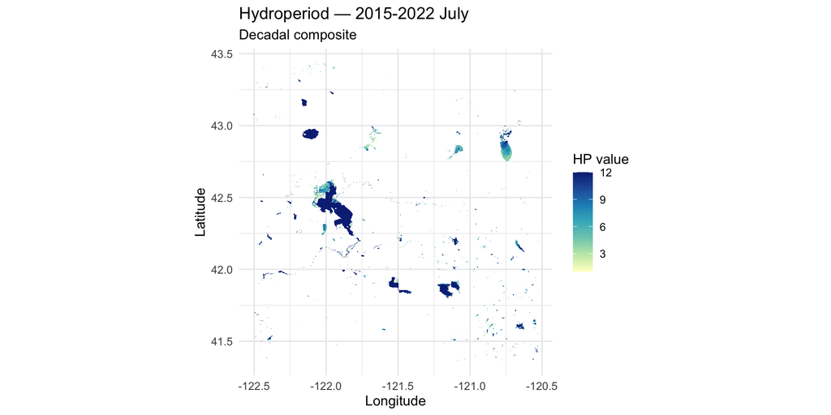

```r
hp_map_file <- file_meta |>
  filter(type == "Hydroperiod", era_str == "2015-2022", month_chr == "JUL") |>
  pull(path)

hp_r <- rast(hp_map_file)
hp_df <- as.data.frame(hp_r, xy = TRUE) |> setNames(c("x", "y", "value"))

ggplot(hp_df, aes(x = x, y = y, fill = value)) +
  geom_raster() +
  scale_fill_distiller(palette = "YlGnBu", direction = 1, na.value = "grey90",
                       name = "HP value") +
  coord_equal() +
  labs(
    title    = "Hydroperiod — 2015-2022 July",
    subtitle = "Decadal composite",
    x = "Longitude", y = "Latitude"
  ) +
  theme_minimal(base_size = 12)
```

# 8. Per-Area Processed Data (Refuges & Lakes)

The processed datasets (`wet_surface_water`, `wet_hydroperiod`) contain per-area statistics extracted from each raster by cropping to bounding boxes (each buffered 0.5 miles) around **six Klamath refuges and five lakes/reservoirs** — `rivermile::klamath_refuges` and `rivermile::klamath_lakes` respectively. Each row’s `name` identifies the area (refuge ids are suffixed `_refuge`, e.g. `clear_lake_refuge`; lake ids are not, e.g. `clear_lake_reservoir`), and `boundary_type` (`"refuge"` or `"lake"`) tells the two apart — see `data-raw/processing-scripts/wet-process-data.R` for how those ids are built, and `data-raw/data-exploration/refuge-elevation-wetland-crosswalk.Rmd` for how they’re crosswalked to water-surface-elevation stations.

Two things changed from the original 6-refuge-only version of this dataset: it now includes lakes as well, and it no longer carries a `pct_wet` column. That column was `mean(value > 0)` — a check for *any* nonzero signal, not “percent flooded” — and it turned out to saturate at `1` for nearly every row (the underlying raster is a continuous ~0–1 signal, not a binary mask), so it was dropped as uninformative. `mean_val` is the column that actually tracks extent/intensity.

`bear_valley_refuge` is expected to be all-`NA` — visual QC confirmed the source rasters have no detected water anywhere inside that refuge’s boundary in any product or era (it’s a small, mostly upland/forested refuge, below this product’s mapping resolution).

## 8.1 Load & preview

```r
data("wet_surface_water", package = "klamathWaterData")
data("wet_hydroperiod",   package = "klamathWaterData")

cat("wet_surface_water:", nrow(wet_surface_water), "rows\n")
```

```
## wet_surface_water: 836 rows
```

```r
cat("wet_hydroperiod:  ", nrow(wet_hydroperiod),   "rows\n\n")
```

```
## wet_hydroperiod:   528 rows
```

```r
kable(
  wet_surface_water |> count(name, boundary_type),
  caption = "Areas represented in wet_surface_water"
)
```

Areas represented in wet_surface_water

| name | boundary_type | n |
| --- | --- | --- |
| bear_valley_refuge | refuge | 76 |
| clear_lake_refuge | refuge | 76 |
| clear_lake_reservoir | lake | 76 |
| gerber_reservoir | lake | 76 |
| klamath_marsh_refuge | refuge | 76 |
| lower_klamath_lake | lake | 76 |
| lower_klamath_sheepy_refuge | refuge | 76 |
| tule_lake | lake | 76 |
| tule_lake_refuge | refuge | 76 |
| upper_klamath_lake | lake | 76 |
| upper_klamath_lake_refuge | refuge | 76 |

```r
kable(head(wet_surface_water), caption = "First rows of wet_surface_water")
```

First rows of wet_surface_water

| name | boundary_type | type | era_str | is_decadal | era_start | month_chr | month_num | mean_val | median_val | sd_val | n_pixels |
| --- | --- | --- | --- | --- | --- | --- | --- | --- | --- | --- | --- |
| bear_valley_refuge | refuge | SurfaceWater | 2005-2014 | TRUE | 2005 | APR | 4 | NaN | NA | NA | 0 |
| clear_lake_refuge | refuge | SurfaceWater | 2005-2014 | TRUE | 2005 | APR | 4 | 0.1654934 | 0.1654812 | 0.0000702 | 112219 |
| klamath_marsh_refuge | refuge | SurfaceWater | 2005-2014 | TRUE | 2005 | APR | 4 | 0.1627350 | 0.1627233 | 0.0001640 | 112048 |
| lower_klamath_sheepy_refuge | refuge | SurfaceWater | 2005-2014 | TRUE | 2005 | APR | 4 | 0.1651718 | 0.1652122 | 0.0001758 | 156301 |
| tule_lake_refuge | refuge | SurfaceWater | 2005-2014 | TRUE | 2005 | APR | 4 | 0.1654357 | 0.1654262 | 0.0000796 | 71383 |
| upper_klamath_lake_refuge | refuge | SurfaceWater | 2005-2014 | TRUE | 2005 | APR | 4 | 0.1639815 | 0.1639921 | 0.0002280 | 609487 |

## 8.2 Surface water — mean value by area & month (decadal eras)

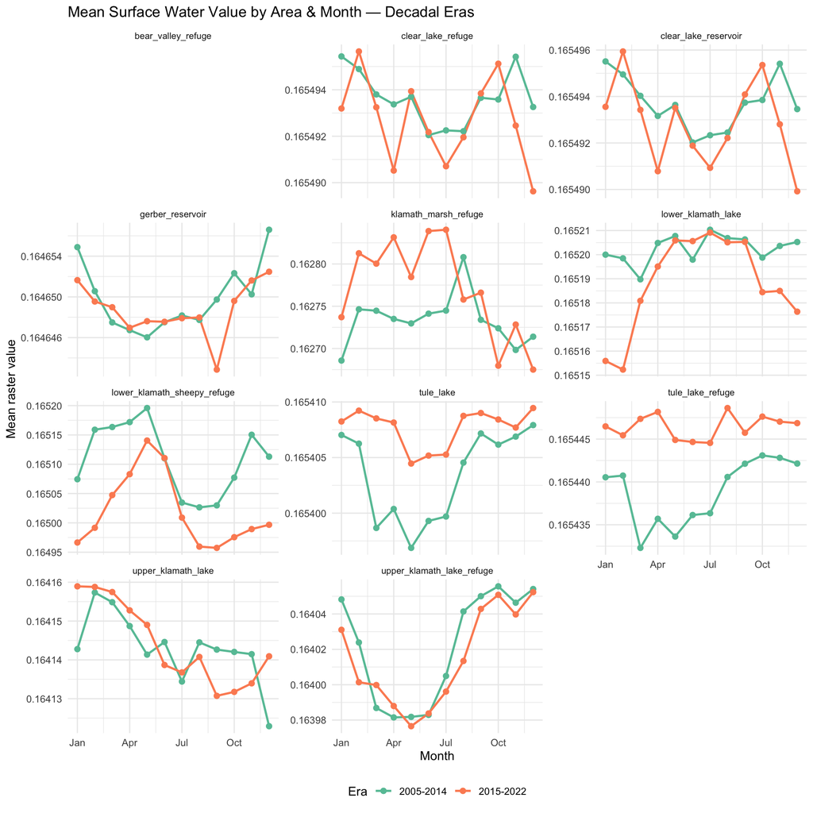

```r
sw_area_decadal <- wet_surface_water |> filter(is_decadal)

ggplot(sw_area_decadal,
       aes(x = month_num, y = mean_val, color = era_str, group = era_str)) +
  geom_line(linewidth = 0.9) +
  geom_point(size = 2) +
  facet_wrap(~name, ncol = 3, scales = "free_y") +
  scale_x_continuous(breaks = c(1, 4, 7, 10), labels = month.abb[c(1, 4, 7, 10)]) +
  scale_color_brewer(palette = "Set2", name = "Era") +
  labs(
    title    = "Mean Surface Water Value by Area & Month — Decadal Eras",
    x        = "Month",
    y        = "Mean raster value"
  ) +
  theme_minimal(base_size = 11) +
  theme(legend.position = "bottom", strip.text = element_text(size = 8))
```

## 8.3 Surface water — annual time series by area (2022–present)

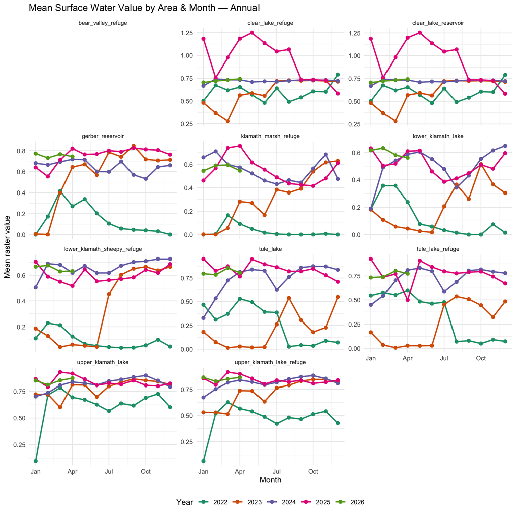

```r
sw_area_annual <- wet_surface_water |> filter(!is_decadal)

ggplot(sw_area_annual,
       aes(x = month_num, y = mean_val, color = factor(era_start), group = era_start)) +
  geom_line(linewidth = 0.9) +
  geom_point(size = 2) +
  facet_wrap(~name, ncol = 3, scales = "free_y") +
  scale_x_continuous(breaks = c(1, 4, 7, 10), labels = month.abb[c(1, 4, 7, 10)]) +
  scale_color_brewer(palette = "Dark2", name = "Year") +
  labs(
    title    = "Mean Surface Water Value by Area & Month — Annual",
    x        = "Month",
    y        = "Mean raster value"
  ) +
  theme_minimal(base_size = 11) +
  theme(legend.position = "bottom", strip.text = element_text(size = 8))
```

## 8.4 Hydroperiod — mean value by area & month

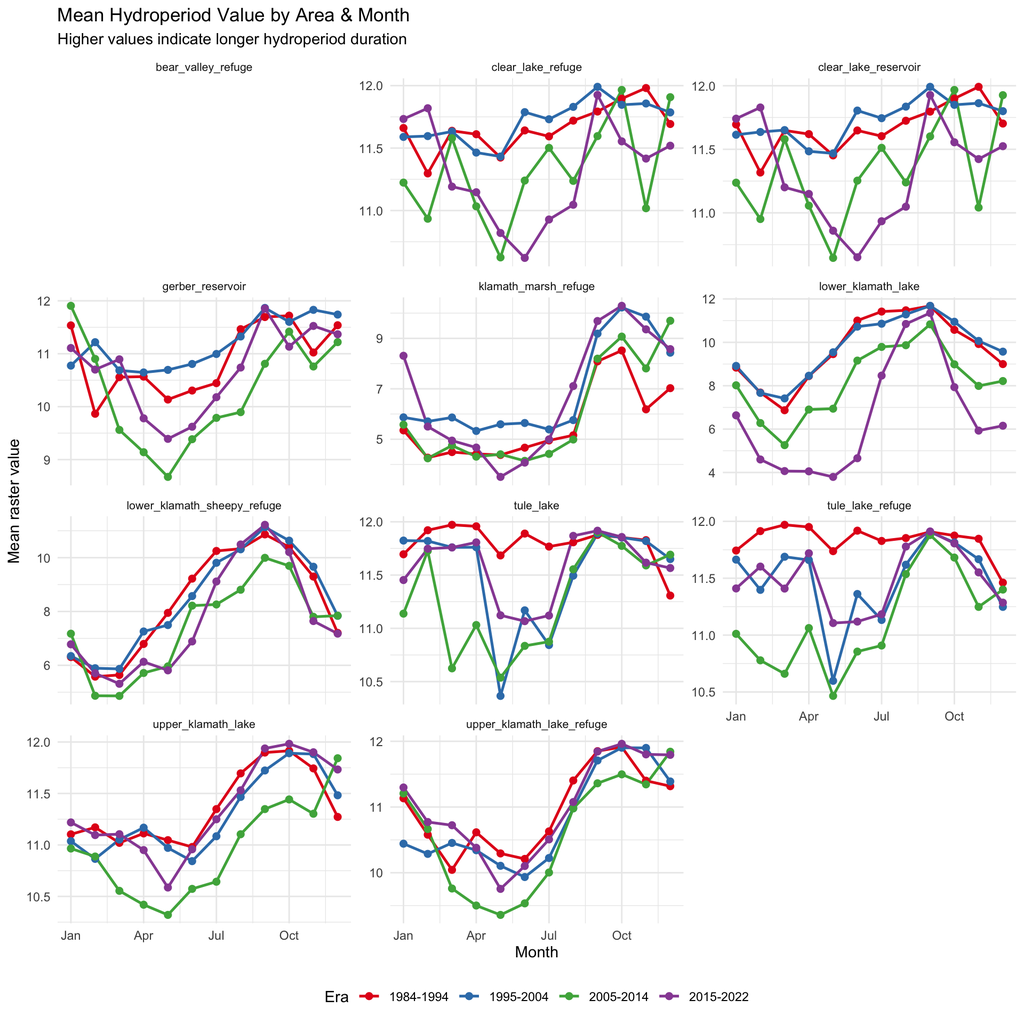

```r
ggplot(wet_hydroperiod,
       aes(x = month_num, y = mean_val, color = era_str, group = era_str)) +
  geom_line(linewidth = 0.9) +
  geom_point(size = 2) +
  facet_wrap(~name, ncol = 3, scales = "free_y") +
  scale_x_continuous(breaks = c(1, 4, 7, 10), labels = month.abb[c(1, 4, 7, 10)]) +
  scale_color_brewer(palette = "Set1", name = "Era") +
  labs(
    title    = "Mean Hydroperiod Value by Area & Month",
    x        = "Month",
    y        = "Mean raster value",
    subtitle = "Higher values indicate longer hydroperiod duration"
  ) +
  theme_minimal(base_size = 11) +
  theme(legend.position = "bottom", strip.text = element_text(size = 8))
```

## 8.5 Cross-area comparison — annual mean surface water

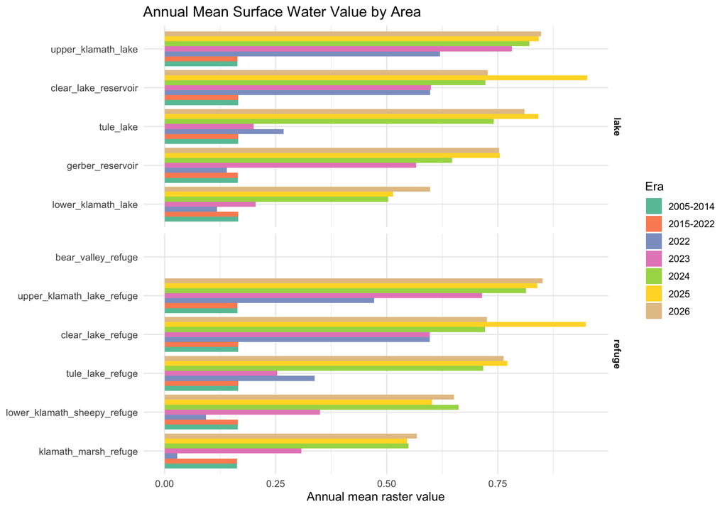

```r
sw_annual_mean <- wet_surface_water |>
  group_by(name, boundary_type, era_str, is_decadal) |>
  summarise(annual_mean_val = mean(mean_val, na.rm = TRUE), .groups = "drop")

ggplot(sw_annual_mean,
       aes(x = reorder(name, annual_mean_val), y = annual_mean_val,
           fill = era_str)) +
  geom_col(position = "dodge") +
  scale_fill_brewer(palette = "Set2", name = "Era") +
  coord_flip() +
  facet_grid(boundary_type ~ ., scales = "free_y", space = "free_y") +
  labs(
    title = "Annual Mean Surface Water Value by Area",
    x     = NULL,
    y     = "Annual mean raster value"
  ) +
  theme_minimal(base_size = 12) +
  theme(strip.text = element_text(face = "bold"))
```

## 8.6 Cross-area comparison — annual mean hydroperiod

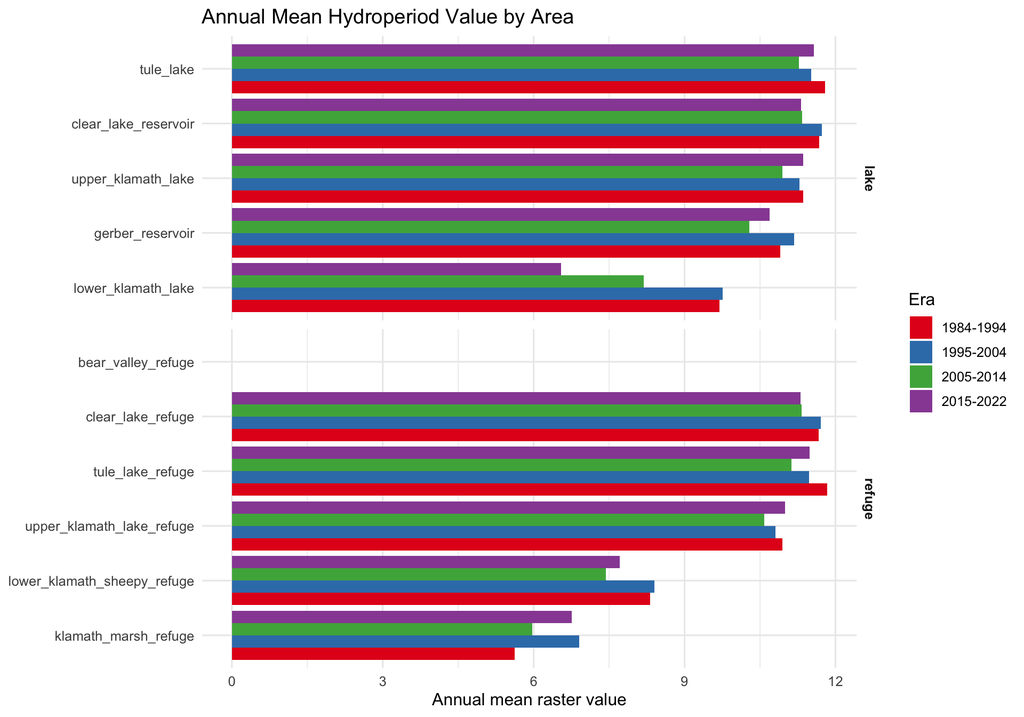

```r
hp_annual_mean <- wet_hydroperiod |>
  group_by(name, boundary_type, era_str) |>
  summarise(annual_mean_val = mean(mean_val, na.rm = TRUE), .groups = "drop")

ggplot(hp_annual_mean,
       aes(x = reorder(name, annual_mean_val), y = annual_mean_val,
           fill = era_str)) +
  geom_col(position = "dodge") +
  scale_fill_brewer(palette = "Set1", name = "Era") +
  coord_flip() +
  facet_grid(boundary_type ~ ., scales = "free_y", space = "free_y") +
  labs(
    title = "Annual Mean Hydroperiod Value by Area",
    x     = NULL,
    y     = "Annual mean raster value"
  ) +
  theme_minimal(base_size = 12) +
  theme(strip.text = element_text(face = "bold"))
```